# Introduction

This is the first installment of Applying Machine Learning to Kaggle Datasets, a series of ipython notebooks demonstrating the methods described in the Stanford Machine Learning Course. In each noteobok, I apply one method taught in the course to an open kaggle competition.

In this notebook, I demonstrate linear regression using the DC Bicycle share competition.

# Outline

1. Import and examine the data
2. Construct a linear model to predicut bicycle usage
3. Optimize model paramters by solving X=y OLS problem
4. Evaluate model results
5. Submit the results to the Kaggle competition

### Import Necessary Modules

```python
%matplotlib inline
import numpy as np
import pandas as pd
import matplotlib.pyplot as plt
import statsmodels.api as sm
import code.Linear_Regression_Funcs as LRF
```

### 1. Read Bicycle Share Data from file

A description of the data can be found here: https://www.kaggle.com/c/bike-sharing-demand/data

```python
train = pd.read_csv("./data/bike_sharing_demand/train.csv",
                   index_col='datetime', parse_dates='datetime')
train.head()
```

| datetime | season | holiday | workingday | weather | temp | atemp | humidity | windspeed | casual | registered | count |
| --- | --- | --- | --- | --- | --- | --- | --- | --- | --- | --- | --- |
| 2011-01-01 00:00:00 | 1 | 0 | 0 | 1 | 9.84 | 14.395 | 81 | 0 | 3 | 13 | 16 |
| 2011-01-01 01:00:00 | 1 | 0 | 0 | 1 | 9.02 | 13.635 | 80 | 0 | 8 | 32 | 40 |
| 2011-01-01 02:00:00 | 1 | 0 | 0 | 1 | 9.02 | 13.635 | 80 | 0 | 5 | 27 | 32 |
| 2011-01-01 03:00:00 | 1 | 0 | 0 | 1 | 9.84 | 14.395 | 75 | 0 | 3 | 10 | 13 |
| 2011-01-01 04:00:00 | 1 | 0 | 0 | 1 | 9.84 | 14.395 | 75 | 0 | 0 | 1 | 1 |

### 2. Construct a linear model to predicut hourly bicycle counts

###### A list of variables to include in the linear model

1. Time variables (Hour of Day, Day of Week, Month of Year, Day of Week * Hour of Day (Interaction))
2. Weather variables (Weather Type: nice, misty, precipitation, nasty)

###### Preparing data for linear regression

1. make vector y: endogenous variable = bicycle count each hour
2. make matrix X: exogenous variables described above
- Before the regression, scale the model by the average number of rides in each:
  - month
  - weather type

```python
y = train['count']
```

```python
# Get dictionaries to hold scale factors for month and weather type
scales = LRF.get_scale(train,['weather','monthly'])
```

```python
# X is an [m x n] matrix.
#    m = number of observations
#    n = number of predictors
X = LRF.make_matrix(train,weather_scale=scales['weather'],monthly_scale=scales['monthly'])
```

### 3. Optimize Model Parameters via OLS regression

Ordinary Least Squares (OLS) assumes a squared loss function with no weights and no regularization.

1. sm.OLS.fit() solves the normal equations to estimate model parameters.
- Pros: exact single step solution
- Cons: does not scale with number of observations
2. sm.OLS.fit_regularized() minimizes the cost function numerically using coordinate descent.
- Pros: poorly conditioned problems can be regularized by early stopping or a regularization term
- Cons: slower for problems of this size, minimization via gradient descent is not implemented in statsmodels.OLS (3 Dec 2014)

```python
results = sm.OLS(y,X).fit()
```

### 4. Evaluate Model Results

```python
# Print OLS regression results and diagnostics
results.summary()
```

OLS Regression Results

| Dep. Variable: | count | R-squared: | 0.963 |
| --- | --- | --- | --- |
| Model: | OLS | Adj. R-squared: | 0.962 |
| Method: | Least Squares | F-statistic: | 1448. |
| Date: | Wed, 03 Dec 2014 | Prob (F-statistic): | 0.00 |
| Time: | 16:31:20 | Log-Likelihood: | -58166. |
| No. Observations: | 10886 | AIC: | 1.167e+05 |
| Df Residuals: | 10693 | BIC: | 1.181e+05 |
| Df Model: | 193 |  |  |
| Covariance Type: | nonrobust |  |  |

|  | coef | std err | t | P>\|t\| | [95.0% Conf. Int.] |
| --- | --- | --- | --- | --- | --- |
| Months_Elapsed_1 | 15.6206 | 8.011 | 1.950 | 0.051 | -0.082 31.323 |
| Months_Elapsed_2 | 20.1382 | 7.359 | 2.736 | 0.006 | 5.712 34.564 |
| Months_Elapsed_3 | 29.6989 | 6.608 | 4.494 | 0.000 | 16.746 42.652 |
| Months_Elapsed_4 | 23.6136 | 5.707 | 4.137 | 0.000 | 12.426 34.801 |
| Months_Elapsed_5 | 18.0927 | 5.543 | 3.264 | 0.001 | 7.227 28.958 |
| Months_Elapsed_6 | 15.1806 | 5.502 | 2.759 | 0.006 | 4.395 25.966 |
| Months_Elapsed_7 | 19.6494 | 5.628 | 3.491 | 0.000 | 8.617 30.682 |
| Months_Elapsed_8 | 29.7368 | 5.749 | 5.173 | 0.000 | 18.468 41.006 |
| Months_Elapsed_9 | 30.8250 | 5.723 | 5.387 | 0.000 | 19.608 42.042 |
| Months_Elapsed_10 | 19.0813 | 5.839 | 3.268 | 0.001 | 7.636 30.526 |
| Months_Elapsed_11 | 23.4614 | 6.077 | 3.861 | 0.000 | 11.549 35.374 |
| Months_Elapsed_12 | 19.6215 | 6.246 | 3.141 | 0.002 | 7.378 31.865 |
| Months_Elapsed_13 | 25.2206 | 5.986 | 4.213 | 0.000 | 13.487 36.955 |
| Months_Elapsed_14 | 19.2910 | 5.496 | 3.510 | 0.000 | 8.518 30.064 |
| Months_Elapsed_15 | 15.1804 | 5.355 | 2.835 | 0.005 | 4.684 25.677 |
| Months_Elapsed_16 | 23.9481 | 5.368 | 4.462 | 0.000 | 13.427 34.469 |
| Months_Elapsed_17 | 20.7854 | 5.288 | 3.931 | 0.000 | 10.421 31.150 |
| Months_Elapsed_18 | 17.6691 | 5.347 | 3.304 | 0.001 | 7.187 28.151 |
| Months_Elapsed_19 | 20.6134 | 5.306 | 3.885 | 0.000 | 10.212 31.014 |
| Months_Elapsed_20 | 22.0085 | 5.292 | 4.159 | 0.000 | 11.635 32.382 |
| Months_Elapsed_21 | 24.8268 | 5.331 | 4.657 | 0.000 | 14.376 35.277 |
| Months_Elapsed_22 | 17.1652 | 5.429 | 3.162 | 0.002 | 6.523 27.807 |
| Months_Elapsed_23 | 22.3705 | 5.510 | 4.060 | 0.000 | 11.570 33.171 |
| Hour_1 | -9.9726 | 8.078 | -1.235 | 0.217 | -25.806 5.861 |
| Hour_2 | -15.9362 | 7.999 | -1.992 | 0.046 | -31.616 -0.256 |
| Hour_3 | -19.1545 | 8.180 | -2.342 | 0.019 | -35.189 -3.120 |
| Hour_4 | -17.9639 | 8.008 | -2.243 | 0.025 | -33.660 -2.268 |
| Hour_5 | -0.1197 | 7.978 | -0.015 | 0.988 | -15.758 15.518 |
| Hour_6 | 73.7026 | 8.031 | 9.178 | 0.000 | 57.961 89.444 |
| Hour_7 | 265.1547 | 8.129 | 32.620 | 0.000 | 249.221 281.088 |

[output cut: 163 more lines]

| Omnibus: | 1688.015 | Durbin-Watson: | 0.755 |
| --- | --- | --- | --- |
| Prob(Omnibus): | 0.000 | Jarque-Bera (JB): | 30329.423 |
| Skew: | 0.023 | Prob(JB): | 0.00 |
| Kurtosis: | 11.177 | Cond. No. | 118. |

```python
# Print score on Kaggle training data
ypredict = results.predict(X)
ypredict[ypredict<0]=0  # Make sure we don't predict negative ridership!
print "score on training data = ", LRF.score(y,ypredict)
```

```
score on training data =  0.463711064666
```

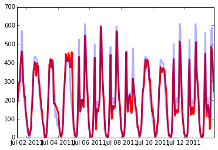

```python
# View Time series of ridership observations and predictions
start = 2700
end = start + 300
#start = 0; end = len(train)-1  # Uncomment to see entire timeseries
plt.plot(train.index[start:end],y[start:end],'-r',alpha=1,lw=3)
plt.plot(train.index[start:end],ypredict[start:end],'-b',alpha=0.3,lw=3)
```

### 5. Submit the results to the Kaggle competition

```python
# Read test data
test = pd.read_csv("./data/bike_sharing_demand/test.csv",
                   index_col='datetime', parse_dates='datetime')
```

```python
# Construct test model matrix
Xtest = LRF.make_matrix(test,weather_scale=scales['weather'],monthly_scale=scales['monthly'])
```

```python
# Calculate predictions by applying model parameters to test model matrix
Ypredict = pd.DataFrame(results.predict(Xtest),index=Xtest.index)
Ypredict = Ypredict.apply(np.round)
Ypredict[Ypredict<0]=0
```

```python
# Write to csv
Ypredict.columns = ['count']
Ypredict = Ypredict.astype(int)  # Force integers in output
Ypredict.to_csv('./predictions/Linear_Regression_Prediction.csv',sep=',')
```

This submission received a score of 0.57986, placing 902 of 1481 submissions. Not bad for a quick linear regression model!

### 6. How to improve the regression model

The evaluation function uses log of rides, so it's very important to be correct when ridership is low.

1. Implement weighted least squares (sm.WLS(y,X)) in which the smaller values of the observations are weighted more heavily.
2. Include more predictor variables. For example, use weather information after transforming it from the raw data. For example, try monthly temperature anomaly instead of simply temperature. Additionally, include an interaction term between temperature anomaly and month of the year (or day of week).
3. Regularize the model results. The test data performs worse than the training data, suggesting that the model overfits the training data. Try early stopping or including a regularization term using OLS.fit_regularlized().
4. Fine tune model predictions. For example, manually reduce ridership predictions during the last week of December, when many people will be out of town or not commuting to work.
5. Assume that the endogenous variable follows a Poisson distribution, not a normal distribution sm.GLM(y,X,family=sm.families.Poisson()). This is cheating a little bit because this tutorial is about linear regression.